# Liza

Olga Alieva

2023-07-21

# Перечитывая “Бедную Лизу”: Sentiment Analysis для сентиментальной прозы

Про “Бедную Лизу” Карамзина все помнят ровно столько, чтобы не стремиться ее перечитывать: бедная крестьянская девушка влюбляется в дворянина, который, разорившись, женится на богатой вдове. Лиза топится в пруду. “Слащавая”, по выражению Вайля и Гениса, повесть об “опереточной” крестьянке и ее “добродетельной” матушке. Чтобы читать Карамзина сегодня, пишут они, нужно запастись “эстетическим цинизмом, позволяющим наслаждаться старомодным простодушием текста”.

Вместо эстетического цинизма мы, однако, запаслись инструментами компьютерного анализа текста, чтобы с их помощью понять: все ли так однозначно и простодушно в этой сентиментальной повести?

Анализ текста проводился на языке R с использованием IDE RStudio. Текст “Лизы” мы забрали с сайта Lib.ru. Для лемматизации ипользовался пакет `udpipe` и модель, обученная на корпусе **СинТагРус** (сокр. от англ. [Syntactically Tagged Russian text corpus](https://urlis.net/2yqwwngu))[^1].

Прежде всего можно заметить, что в тексте часто встречаются слова “мать”, “матушка”, “старушка” (42 раза): Лизина мать упоминается в тексте так же часто, как Эраст, и чаще, чем слова “сердце” (24) и “слеза” (15).

```
## # A tibble: 9 × 2
##   lemma        n
##   <chr>    <int>
## 1 Лиза       107
## 2 Эраст       41
## 3 сердце      24
## 4 мать        21
## 5 слеза       15
## 6 матушка     11
## 7 старушка    10
## 8 любовь       9
## 9 девушка      6
```

Список самых частотных существительных для повести выглядит так:

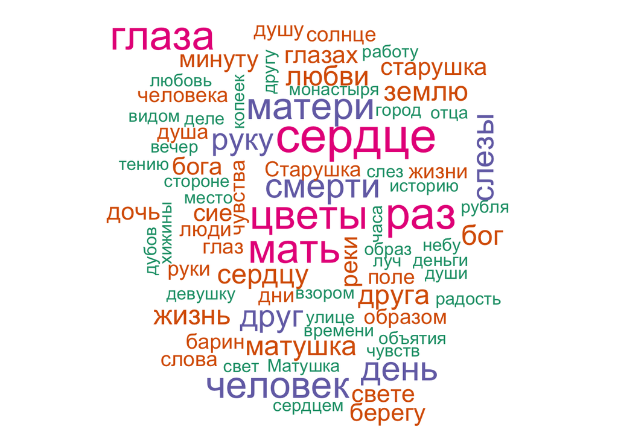

В любовной повести Карамзин чуть ли не чаще говорит о матери героини, чем о её возлюбленном! Как отмечали исследователи, подобная проверка чувства доверием к родителям – не новый в литературе мотив. В “Лизе”, однако, мать выступает не только в роли заботливой наставницы, но и безвинной жертвы. Перед самоубийством дочь передает матери 10 империалов – получив такой подарок с таким известием, та умирает от ужаса.

Разделив весь текст “Лизы” на отрывки по 100 слов, мы решили проверить, как меняется эмоциональная тональность произведения по мере развития сюжета. В тексте чуть более 5000 слов, у нас получился 51 отрывок. Для анализа эмоциональной тональности мы выбрали лексикон AFINN, доступный в пакете `rulexicon`. Он содержит около 7268 слов. Их тональность оценивается по шкале от -5 (крайне негативная) до 5 (в высшей степени положительная). Например, слово “адский” имеет оценку -5, а слово “ангельский” – +5. Слово “старый” имеет в этом лексиконе отрицательную оценку, что не соответствует словоупотреблению Карамзина, и мы его удалили; слову “чувствительный” поменяли знак с минуса на плюс, поскольку для автора “Бедной Лизы” это скорее положительное качество.

Сложив затем положительно и отрицательно окрашенную лексику для каждого отрывка, мы получили значение, позволяющее судить о доминирующей тональности.

```
## # A tibble: 10 × 2
##    chunk   sum
##    <dbl> <dbl>
##  1     5 -43.3
##  2    34 -35.8
##  3    31 -25
##  4    38 -20
##  5    42 -20
##  6    50 -20
##  7     3 -15.7
##  8    51 -15
##  9     4 -14.2
## 10    46 -13.3
```

Довольно неожиданно, что самый негативный отрывок находится не в конце повести, ближе к трагической ее развязке, а почти в начале (отрывок 5, ср. отрывки 3 и 4 рядом). Представим эмоционально окрашенную лексику отрывков 3-5 в виде сравнительного облака слов:

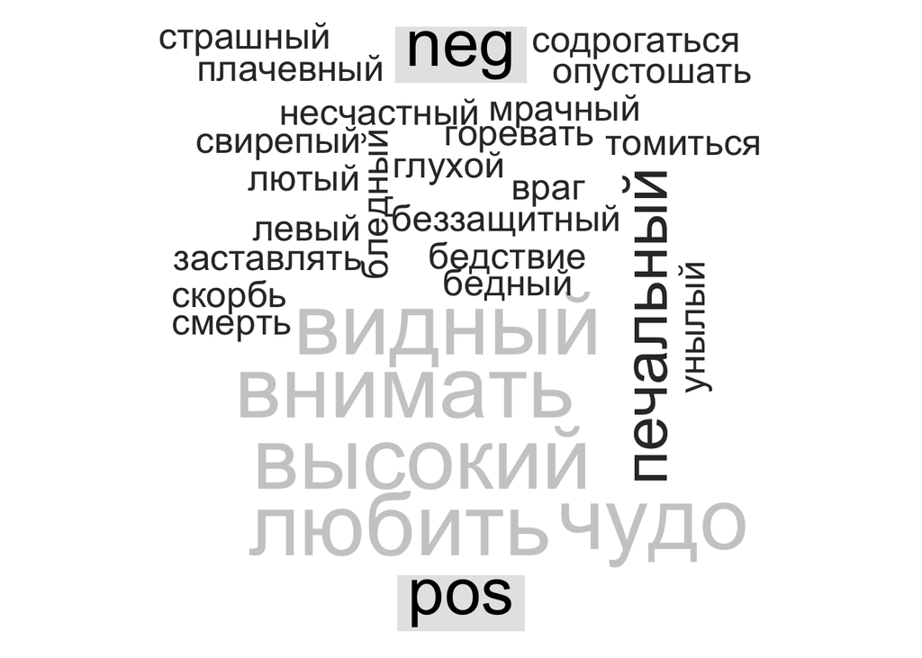

Здесь видно, что негативная тональность в этой части не связана с судьбой героев: об этом говорят такие слова, как “лютый”, “враг”, “свирепый”. Рассказчик, глядя на заброшенный Симонов монастырь, вспоминает о “печальной истории” Москвы. Таким образом, **с количественной точки зрения, самые мрачные фрагменты повести посвящены не судьбе бедной девушки, а “глухому стону времен”**: Карамзин-историк уже переигрывает Карамзина-новелиста.

Приведем небольшой отрывок из этой части повести:

> Иногда на вратах храма рассматриваю изображение чудес, в сем монастыре случившихся, там рыбы падают с неба для насыщения жителей монастыря, осажденного многочисленными врагами; тут образ богоматери обращает неприятелей в бегство. Все сие обновляет в моей памяти историю нашего отечества — печальную историю тех времен, когда свирепые татары и литовцы огнем и мечом опустошали окрестности российской столицы и когда несчастная Москва, как беззащитная вдовица, от одного бога ожидала помощи в лютых своих бедствиях.

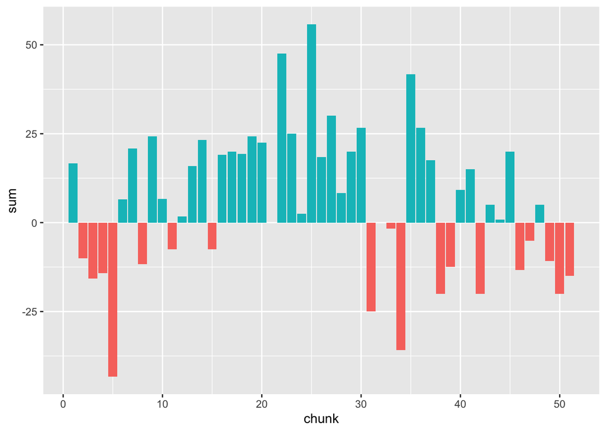

Немного скорби в отрывке 8 посвящено покойному отцу Лизы. В 11-м отрывке отразилась тревога матери за судьбу дочери: “коварно”, “обидеть”, “дурной” вносят вклад в настроение этого фрагмента. Это достаточно характерно для сентиментальной прозы с ее противопоставлением пороков городской жизни и пасторальных добродетелей.

> У меня всегда сердце бывает не на своем месте, когда ты ходишь в город; я всегда ставлю свечу перед образ и молю господа бога, чтобы он сохранил тебя от всякой беды и напасти.

В отрывке 15 несколько негативных слов имеют перед собой отрицания (“не подозревая”, “никакого худого намерения” и т.п.), поэтому к числу отрицательно окрашенных он отнесен ошибочно.

Еще два минимума: отрывки 31 и 34. В первом из них Лиза встревожена вестью о возможном замужестве с сыном крестьянина. Отрывок 34 – это падение Лизы:

> Грозно шумела буря, дождь лился из черных облаков — казалось, что натура сетовала о потерянной Лизиной невинности.

На графике видно, что **это место гораздо более эмоционально, чем эпизод самоубийства Лизы**: именно после знаменитых карамзинских многоточий и тире события устремляются к трагическому финалу. О самой смерти девушки Карамзин говорит, конечно, с грустью, но без надрыва: “Тут она бросилась в воду”.

38, 39, 42 – Эраст отправляется на войну. Все, как это принято у Карамзина, плачут, что зафиксировал и наш график.

Наконец, в отрывках 49-51 доминирует тема смерти:

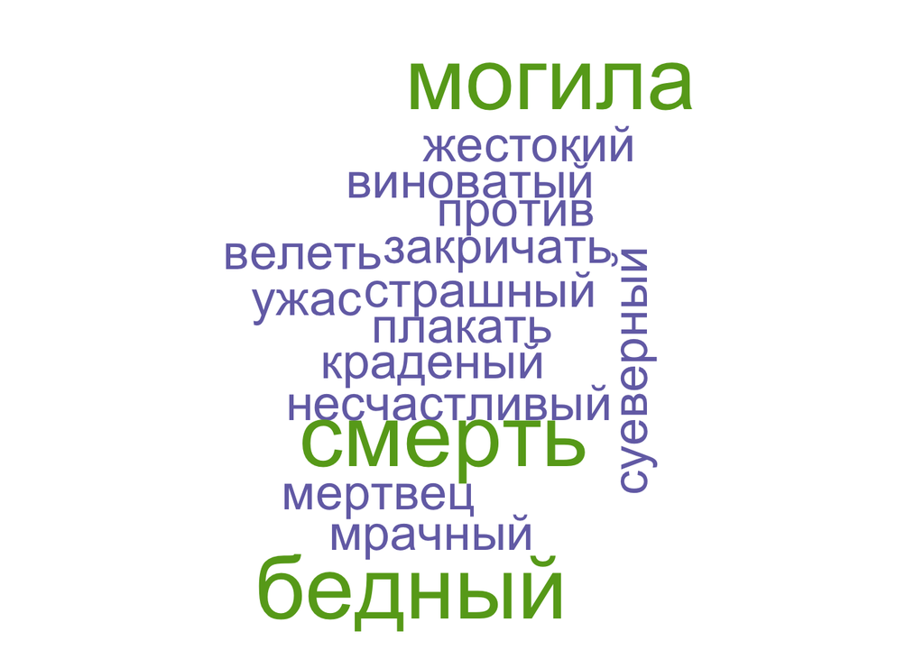

Следует отметить, что часть этих слов относится не к самой девушке, а к ее матери.

> Лизина мать услышала о страшной смерти дочери своей, и кровь ее от ужаса охладела — глаза навек закрылись.

Эта вторая смерть для большинства читателей остается незаметна. Лиза умирает на сцене – старушка за кулисами. Образ ее опустевшей хижины возвращает читателя к образу опустевшего монастыря и “беззащитной вдовицы”, а стоны бедной Лизы, пугающие суеверных поселян, сливаются с “глухим стоном времен”. Упоенная своим горем, Лиза не думает о том, что убивает мать, которой в начале повести она обещала свою вечную заботу. Но мудрый рассказчик, никого не обвиняя, ни о чем не умалчивает – и знаменитые слова о том, что “крестьянки любить умеют” относятся не Лизе, а к ее матери, трогательно ожидающей встречи со своим мужем на том свете. С мужем, о котором известно лишь то, что звали его заурядным именем Иван и жил он со своей женой в согласии.

*Все сказанное следует понимать лишь как читательский опыт, не претендующий на литературоведческую основательность.*

[^1]: https://universaldependencies.org/treebanks/ru_syntagrus/index.html